# Exploration of navigation length code

Setup: A 360 time step run was completed on a login node. Afterwards, the state of the model after the final step was probed in the console. (we wanted to look at a snapshot of navigation lengths- I chose the final time step)

```r
start <- net.f %v% "navigation_start_time"
end <- net.f %v% "navigation_end_time"
```

Central tendency measures:

```r
mean(navigation.length[which(navigation.length > 0)])
```

```
[1] 102.5252
```

```r
median(navigation.length[which(navigation.length > 0)])
```

```
[1] 140
```

Number of agents with navigations that last longer than 12 months:

```r
length(which(navigation.length > 12))
```

```
[1] 1715
```

Number of agents with navigation length greater than 0:

```r
length(which(navigation.length > 0))
```

```
[1] 2222
```

Number of navigations which had no end time at time 360:

```r
length(intersect(which(start > 0), which(end == 0)))
```

```
[1] 113
```

```r
nav_start_not_end
```

```
  [1]    4   29   72   81  197  253  285  314  398  429  492  498  504  518  550  634  664  683  730  795  817
 [22]  824  870  879  968 1007 1023 1093 1114 1170 1287 1339 1379 1394 1412 1416 1428 1437 1505 1520 1559 1686
 [43] 1702 1740 1823 1833 1867 2073 2076 2093 2151 2173 2205 2216 2243 2337 2412 2432 2510 2561 2672 2713 2735
 [64] 2838 2889 3032 3087 3167 3203 3225 3246 3247 3309 3407 3479 3528 3556 3614 3746 3748 3772 3788 3929 3932
 [85] 3958 3973 4010 4014 4023 4043 4111 4148 4151 4175 4177 4296 4359 4457 4532 4596 4657 4667 4699 4772 4841
[106] 4872 4887 4896 4929 4954 4965 4991 5000
```

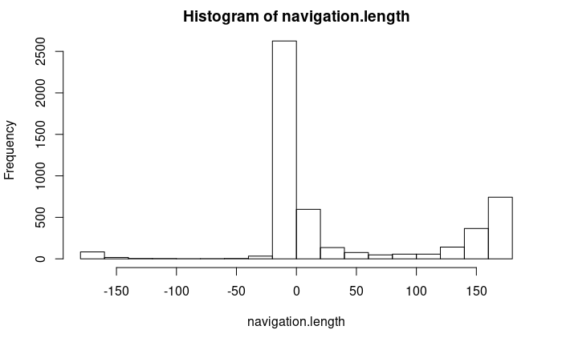

```r
hist(navigation.length)
```

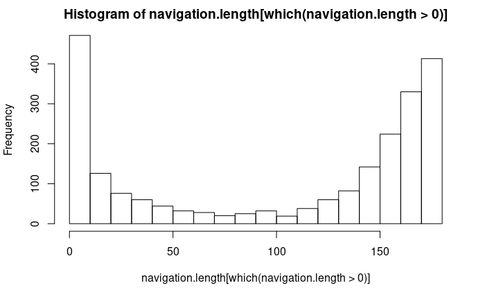

```r
hist(navigation.length[which(navigation.length > 0)])
```

Why are there so many navigation.length = 1 agents?

Including zero:

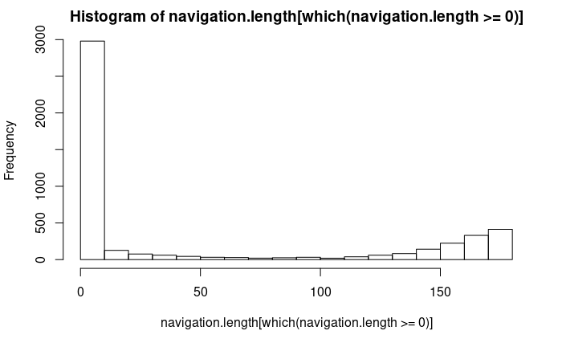

```r
hist(navigation.length[which(navigation.length >= 0)])
```

```r
mean(navigation.length[which(navigation.length > 0)])
```

```
[1] 102.5252
```

```r
median(navigation.length[which(navigation.length > 0)])
```

```
[1] 140
```

How many agents have start and end = 0? (no navigation)

```r
n_no_nav <- length(navigation.length[intersect(which(start == 0), which(end == 0))])
n_no_nav
```

```
[1] 2346
```

Do the numbers add up to 5000?

```r
nav_completed <- length(intersect(which(end != 0), which(start < end)))
nav_overwrite <- length(intersect(which(end < start), which(end != 0)))
nav_started_and_ended <- length(intersect(which(end != 0), which(end > start)))

n_no_nav + length(nav_start_not_end) + nav_completed + nav_overwrite
```

```
[1] 4879
```

```r
#nav_start_not_end <- intersect(which(start > 0), which(end == 0))
#n_no_nav <- length(navigation.length[intersect(which(start == 0), which(end == 0))])
```

The numbers don’t quite add up. Either there is an issue, or my cases are incorrect.

Agents with negative navigation lengths: (navigation.length = nav.end.time - nav.start.time. Negative value means at least one navigation has ended and another has started, hence end time is lower than start time)

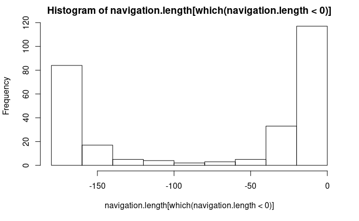

```r
hist(navigation.length[which(navigation.length < 0)])
```

CONCLUSIONS:

1. MANY agents have very long navigation lengths. We should implement a referral timeout. Currently, navigation ends only when the referrals are completed. From this we can infer than many agents are not completing their referrals in a reasonable amount of time.
2. We should implement a per-agent counting of number of times navigated (easy) . We haven’t looked at this at all.
3. navigation_length data doesn’t fit well into the multiplot.R data management scheme. It pulls data from n.data output files, which only record summary data, not per agent data like nav_length would need to be.
4. A similar analysis could be done for testing_length (not a great name), which I’m imagining as the time from referral to diagnostic test completion. We could compare the lengths as a way of seeing the effect of navigation

QUESTIONS:

*Do we need to factor in diagnosed agents? (note: these seem to be NAs:)

```r
length(which(net.f %v% "diagnosed" == 0))
```

```
[1] 0
```

*What does it mean about our calibration in terms of referral completions? Does this match Yami’s expectations/data? Particularly, we have many 1 month completions, and many 150+ month navigations.

*Screening visits- I was poking around the model and noticed that many women have no screening visits. Perhaps this is where navigated agents are getting stuck?

```r
table(net.f %v% "diagnostic_visit_counter")
```

```
   0    1    2    3    4
4524  407   57   11    1
```

```r
table(net.f %v% "screening_visit_counter")
```

```
   0    1    2    3    4    5    6    7    8    9   10   11   12   13   14   15   16   17   20
2397 1152  609  350  181  104   76   50   19   16   14   10    4    4    3    5    2    1    3
```

```r
length(which(navigation.length > 100))
```

```
[1] 1308
```

- on this note, we se very few women with significant numbers of screening referrals. We would expect older women to have 1 screening per two years. We’d need to look into measuring women’s number of time steps in the model to see if our numbers are reasonable (because nintros are generated with an age probabilistically- they don’t just age in). Mickey has talked about “ageing in”, but since nintros are the only new nodes due to our in-place replacement scheme there really is no “ageing in” to speak of.

This makes us unable to cross-reference age and expected screenings, since we only measure screenings that happen while agents are in the model. e.g. If someone ages in at 50 and we measure them at 74, we’d expect around 12 screenings. But if someone replaces a dead agent and rolls that they’ll start at 74 they will only show up as having 0 (or possibly 1) screenings.

As we can see below, we have a sizeable number of 70+ agents, but we have no idea how long we’ve been tracking their screenings.

```r
age <- net.f %v% "age"
length(which(age > 70))
```

```
[1] 964
```